None

# HOME CREDIT MODELING ASSIGNMENT GROUP 2

## Introduction

**Project Goal:**

Home Credit will be able to identify if a customer is a safe candidate to lend to, then create a personalized customer loan and repayment plan to be accountable for, resulting in an increase in revenue, improved customer experience, and lower default rates.

**Business Problem:**

Home Credit desires to know safe borrowers in a customer base that is unfamiliar with banking and give the customer a plan for successful loan repayment. Lending to those who are more likely to default on loans decreases the profits of Home Credit and results in negative customer experiences.

**Analytic Problem:**

The target variable is specificially customers that do have a negative history of repayment to lend to, and postive repayment. Represented in the application_train/test.csv sets of binary where 1 = Not trust worthy borrower (Client with payment difficulties), 0 = Trustworthy borrower (client with good repayment history).

**The Purpose of this Notebook:**

- Evalaute and test different machine learning models to learn more about Customer Behaviors
- Predict which customers will be good borrowers, using a classification method based on customer financial behavior data.
- Use a machine learning method to see the relationship that a trust worthy customer has to other attributes about them.

# Data Preparation

## Importing Necessary Packages

```python
import importlib

# List of required packages
required_packages = [
    'pandas',
    'numpy',
    'matplotlib',
    'xgboost',
    'imbalanced-learn',
    'scipy',
    'sklearn',
]

# Check and install missing packages
for package in required_packages:
    try:
        importlib.import_module(package)
        print(f"{package} is already installed.")
    except ImportError:
        print(f"{package} is not installed. Installing...")
        !pip install {package}

# Import the required modules
import pandas as pd
import numpy as np
import matplotlib as mpl
import matplotlib.pyplot as plt
import xgboost as xgb

from sklearn.model_selection import train_test_split
from sklearn.model_selection import cross_val_score
from sklearn.ensemble import RandomForestClassifier
from sklearn.metrics import accuracy_score
from sklearn.preprocessing import PolynomialFeatures
from sklearn.linear_model import LogisticRegression
from sklearn.metrics import accuracy_score, roc_auc_score
from sklearn.ensemble import RandomForestClassifier, GradientBoostingClassifier
from sklearn.metrics import accuracy_score, roc_auc_score
from sklearn.preprocessing import StandardScaler, MinMaxScaler, OneHotEncoder
import numpy as np

from sklearn.utils import resample
from sklearn.model_selection import train_test_split
from sklearn.metrics import accuracy_score
from sklearn.linear_model import LogisticRegression
import pandas as pd

from sklearn.ensemble import VotingClassifier
from sklearn.model_selection import cross_val_score

from sklearn.model_selection import GridSearchCV
from sklearn.ensemble import RandomForestClassifier

from sklearn.metrics import classification_report, roc_auc_score

# from imblearn.over_sampling import RandomOverSampler
from scipy.stats import randint, uniform
from sklearn.model_selection import train_test_split, GridSearchCV, RandomizedSearchCV, cross_val_score
from sklearn.preprocessing import OneHotEncoder, StandardScaler
from sklearn.impute import SimpleImputer
from sklearn.metrics import accuracy_score, classification_report, roc_auc_score, confusion_matrix
from sklearn.ensemble import RandomForestClassifier

# Additional configurations or settings
import warnings
warnings.filterwarnings('ignore')
%matplotlib inline
```

```
pandas is already installed.
numpy is already installed.
matplotlib is already installed.
xgboost is already installed.
imbalanced-learn is not installed. Installing...
sklearn is already installed.
```

*Many of these packages have already been installed. Each of these packages serves different purposes within our code for each of the modeling. All of the packages have imported correctly and have succesfully been installed for use.*

## Making the dataframes for each of our CSV files

```python
# Making Dataframes of each of the CSV Files

applicationtestDF = pd.read_csv("application_test.csv")
applicationtrainDF = pd.read_csv("application_train.csv")
bureauDF = pd.read_csv("bureau.csv")
bureaubalanceDF = pd.read_csv("bureau_balance.csv")
creditcardbalanceDF = pd.read_csv("credit_card_balance.csv")
installmentpaymentsDF = pd.read_csv("installments_payments.csv")
poscashDF = pd.read_csv("POS_CASH_balance.csv")
previousDF = pd.read_csv("previous_application.csv")
```

```python
#Shape of datasets
print(applicationtestDF.shape)
print(applicationtrainDF.shape)
print(bureauDF.shape)
print(bureaubalanceDF.shape)
print(creditcardbalanceDF.shape)
print(installmentpaymentsDF.shape)
print(poscashDF.shape)
print(previousDF.shape)
```

```
(48744, 121)
(307511, 122)
(1716428, 17)
(27299925, 3)
(3840312, 23)
(13605401, 8)
(10001358, 8)
(1670214, 37)
```

*Each of the CSV were loaded and installed succcessfully. Due to the size of each of the CSV files, we have to be selected as to what files to use because it would require too much computation power to use all. Many of the CSV files have data points that are shared in commmon with other files. We will go into more analysis of which ones to combine into our aggregation of the data sets in our future analysis*

## Combining the DFs for our Analysis

*The original approach that we took to getting the DF into one comnbined Dataframe to analyze as best as possible was to take this approach*

```python
# # # Combine the DataFrames
# combined_df = pd.concat([applicationtestDF, applicationtrainDF, bureauDF, bureaubalanceDF,
#                          creditcardbalanceDF, installmentpaymentsDF, poscashDF, previousDF])


# Remove missing values (NA)
# combined_df = combined_df.dropna()

# # Remove duplicates from the combined DataFrame
# combined_df = combined_df.drop_duplicates()

# # Reset the index
# combined_df = combined_df.reset_index(drop=True)

# # Print the head of the combined DataFrame
# combined_df.head()


# # Print the data types of each column
# combined_df.dtypes
```

*However, this approach took up too much computational power to execute due to the size of the data. The append() function was then tried to be used other than the concat() to save memory. This execution was not very appropriate because each of our devices did not have the computation power at first to just combine all datasets into one. We then had decided to continue on and try to use CSV files that we felt are only relevant to our analysis*

```python
# combined_df = pd.DataFrame()  # Initialize an empty DataFrame

# # List of DataFrames to be combined
# dataframes = [applicationtestDF, applicationtrainDF, bureauDF, bureaubalanceDF,
#               creditcardbalanceDF, installmentpaymentsDF, poscashDF, previousDF]

# # Combine DataFrames in smaller batches
# for df in dataframes:
#     combined_df = combined_df.append(df, ignore_index=True)

# # Remove missing values (NA)
# combined_df = combined_df.dropna()

# # Remove duplicates from the combined DataFrame
# combined_df = combined_df.drop_duplicates()

# # Reset the index
# combined_df = combined_df.reset_index(drop=True)

# # Print the head of the combined DataFrame
# combined_df.head()

# # Print the data types of each column
# combined_df.dtypes
```

*This method did not work. So We then aggregated some of the values based upon the averages of each datasets. We thought the count of days since overdue payments on both credit card balance and the bureau tables would be good to examine.This method gave us a much better output. By using merge() rather than concat() we are able to merge datasets that fit within computation and add elements to understand for our modeling. We have chosen the creditcardbalance and bureauDF because these dataframes contain much of the same info from the other DF. This information also can tell us how customer behavior may lead to default.*

```python
#Calculate average 'SK_DPD' values in credit_card_balance.csv
average_sk_dpd = creditcardbalanceDF.groupby('SK_ID_CURR')['SK_DPD'].mean().reset_index()

#Merge average_sk_dpd with train_data based on 'SK_ID_CURR'
train_data = applicationtrainDF.merge(average_sk_dpd, on='SK_ID_CURR', how='left')

#Merge average_sk_dpd with test_data based on 'SK_ID_CURR'
test_data = applicationtestDF.merge(average_sk_dpd, on='SK_ID_CURR', how='left')

#Fill missing values with 0
train_data['SK_DPD'] = train_data['SK_DPD'].fillna(0)
test_data['SK_DPD'] = test_data['SK_DPD'].fillna(0)

#Calculate average 'CREDIT_DAY_OVERDUE' values in bureau.csv
average_credit_day_overdue = bureauDF.groupby('SK_ID_CURR')['CREDIT_DAY_OVERDUE'].mean().reset_index()

#Merge average_credit_day_overdue with train_data based on 'SK_ID_CURR'
train_data = train_data.merge(average_credit_day_overdue, on='SK_ID_CURR', how='left')

#Merge average_credit_day_overdue with test_data based on 'SK_ID_CURR'
test_data = test_data.merge(average_credit_day_overdue, on='SK_ID_CURR', how='left')

#Fill missing values with 0
train_data['CREDIT_DAY_OVERDUE'] = train_data['CREDIT_DAY_OVERDUE'].fillna(0)
test_data['CREDIT_DAY_OVERDUE'] = test_data['CREDIT_DAY_OVERDUE'].fillna(0)

#Shape of the joined datasets
print(train_data.shape)
print(test_data.shape)

#First 10 rows on the joined dataset
train_data.head(10)
```

```
(307511, 124)
(48744, 123)
```

|  | SK_ID_CURR | TARGET | NAME_CONTRACT_TYPE | CODE_GENDER | FLAG_OWN_CAR | FLAG_OWN_REALTY | CNT_CHILDREN | AMT_INCOME_TOTAL | AMT_CREDIT | AMT_ANNUITY | ... | FLAG_DOCUMENT_20 | FLAG_DOCUMENT_21 | AMT_REQ_CREDIT_BUREAU_HOUR | AMT_REQ_CREDIT_BUREAU_DAY | AMT_REQ_CREDIT_BUREAU_WEEK | AMT_REQ_CREDIT_BUREAU_MON | AMT_REQ_CREDIT_BUREAU_QRT | AMT_REQ_CREDIT_BUREAU_YEAR | SK_DPD | CREDIT_DAY_OVERDUE |
| --- | --- | --- | --- | --- | --- | --- | --- | --- | --- | --- | --- | --- | --- | --- | --- | --- | --- | --- | --- | --- | --- |
| 0 | 100002 | 1 | Cash loans | M | N | Y | 0 | 202500.0 | 406597.5 | 24700.5 | ... | 0 | 0 | 0.0 | 0.0 | 0.0 | 0.0 | 0.0 | 1.0 | 0.0 | 0.0 |
| 1 | 100003 | 0 | Cash loans | F | N | N | 0 | 270000.0 | 1293502.5 | 35698.5 | ... | 0 | 0 | 0.0 | 0.0 | 0.0 | 0.0 | 0.0 | 0.0 | 0.0 | 0.0 |
| 2 | 100004 | 0 | Revolving loans | M | Y | Y | 0 | 67500.0 | 135000.0 | 6750.0 | ... | 0 | 0 | 0.0 | 0.0 | 0.0 | 0.0 | 0.0 | 0.0 | 0.0 | 0.0 |
| 3 | 100006 | 0 | Cash loans | F | N | Y | 0 | 135000.0 | 312682.5 | 29686.5 | ... | 0 | 0 | NaN | NaN | NaN | NaN | NaN | NaN | 0.0 | 0.0 |
| 4 | 100007 | 0 | Cash loans | M | N | Y | 0 | 121500.0 | 513000.0 | 21865.5 | ... | 0 | 0 | 0.0 | 0.0 | 0.0 | 0.0 | 0.0 | 0.0 | 0.0 | 0.0 |
| 5 | 100008 | 0 | Cash loans | M | N | Y | 0 | 99000.0 | 490495.5 | 27517.5 | ... | 0 | 0 | 0.0 | 0.0 | 0.0 | 0.0 | 1.0 | 1.0 | 0.0 | 0.0 |
| 6 | 100009 | 0 | Cash loans | F | Y | Y | 1 | 171000.0 | 1560726.0 | 41301.0 | ... | 0 | 0 | 0.0 | 0.0 | 0.0 | 1.0 | 1.0 | 2.0 | 0.0 | 0.0 |
| 7 | 100010 | 0 | Cash loans | M | Y | Y | 0 | 360000.0 | 1530000.0 | 42075.0 | ... | 0 | 0 | 0.0 | 0.0 | 0.0 | 0.0 | 0.0 | 0.0 | 0.0 | 0.0 |
| 8 | 100011 | 0 | Cash loans | F | N | Y | 0 | 112500.0 | 1019610.0 | 33826.5 | ... | 0 | 0 | 0.0 | 0.0 | 0.0 | 0.0 | 0.0 | 1.0 | 0.0 | 0.0 |
| 9 | 100012 | 0 | Revolving loans | M | N | Y | 0 | 135000.0 | 405000.0 | 20250.0 | ... | 0 | 0 | NaN | NaN | NaN | NaN | NaN | NaN | 0.0 | 0.0 |

10 rows × 124 columns

*This method worked a lot better to get our dataframes merged to set aside for our testinga and training datasets.*

## Cleaning Data

*The majority of the EDA examination and visuals were completed in the EDA portion of this project that was previously turned in. I did implement some of the strategies that we suggested in that assignment. I dropped any column that was missing more than 30% of it's values and imputed the mean value for columns with less than 30% null values.*

### Missing Data

```python
#Calculate the null count and percentage for all columns
null_counts = train_data.isnull().sum()
null_percentages = (null_counts / len(train_data)) * 100

#Create a DataFrame to display the results
null_info = pd.DataFrame({
    'Column': null_counts.index,
    'Null Count': null_counts,
    'Null Percentage': null_percentages
})

#Sort the DataFrame by null percentages in descending order
null_info_sorted = null_info.sort_values('Null Percentage', ascending=False)

#Print the columns with null values and their percentages
print("Columns with null values (sorted by null percentages):")
print(null_info_sorted)
```

```
Columns with null values (sorted by null percentages):
                                            Column  Null Count  \
COMMONAREA_MODE                    COMMONAREA_MODE      214865
COMMONAREA_AVG                      COMMONAREA_AVG      214865
COMMONAREA_MEDI                    COMMONAREA_MEDI      214865
NONLIVINGAPARTMENTS_MEDI  NONLIVINGAPARTMENTS_MEDI      213514
NONLIVINGAPARTMENTS_AVG    NONLIVINGAPARTMENTS_AVG      213514
...                                            ...         ...
FLAG_EMAIL                              FLAG_EMAIL           0
FLAG_PHONE                              FLAG_PHONE           0
FLAG_CONT_MOBILE                  FLAG_CONT_MOBILE           0
FLAG_WORK_PHONE                    FLAG_WORK_PHONE           0
CREDIT_DAY_OVERDUE              CREDIT_DAY_OVERDUE           0

                          Null Percentage
COMMONAREA_MODE                 69.872297
COMMONAREA_AVG                  69.872297
COMMONAREA_MEDI                 69.872297
NONLIVINGAPARTMENTS_MEDI        69.432963
NONLIVINGAPARTMENTS_AVG         69.432963
...                                   ...
FLAG_EMAIL                       0.000000
FLAG_PHONE                       0.000000
FLAG_CONT_MOBILE                 0.000000
FLAG_WORK_PHONE                  0.000000
CREDIT_DAY_OVERDUE               0.000000

[124 rows x 3 columns]
```

*This output tells us that these columns within our data were removed because of the lack of values within each of the columns. For example we see that the column COMMONAREA_MODE has 214,865 Null Values, meaning about 69.87% of the values in this column were Null.*

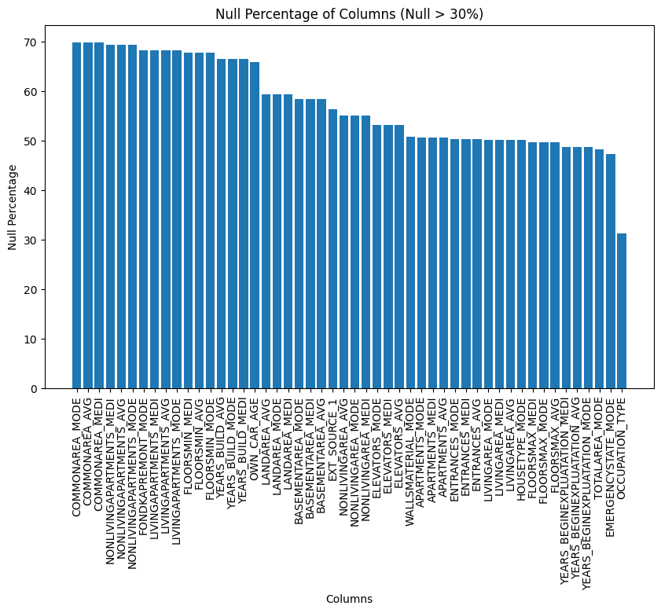

```python
#Plotting the null values

#Filter the DataFrame for columns with null percentages greater than 30%
filtered_null_info = null_info_sorted[null_info_sorted['Null Percentage'] > 30]

# Set the figure size
plt.figure(figsize=(10, 6))

#Create the bar plot
plt.bar(filtered_null_info['Column'], filtered_null_info['Null Percentage'])
plt.xticks(rotation='vertical')
plt.xlabel('Columns')
plt.ylabel('Null Percentage')
plt.title('Null Percentage of Columns (Null > 30%)')

#Show the plot
plt.show()
```

*Here we see the plotted the columns that have a Null Percentage that is Greater than 30%. We see here that within our dataframe we have a lot of columns that may not contribute very much to our analysis because they have so many null values. Including these columns in our analysis may not allow us to conduct our analysis as much as we can. We see many of our data are not useful because they have so many null values.*

```python
#Remove columns with more than 30% null values
train_data = train_data.dropna(thresh=len(train_data) * 0.7, axis=1)
test_data = test_data.dropna(thresh=len(test_data) * 0.7, axis=1)

#Select valid numeric columns
numeric_columns = train_data.select_dtypes(include=np.number).columns

#Impute mean for numeric columns with less than 30% null values in train_data
train_data = train_data.loc[:, numeric_columns].fillna(train_data.loc[:, numeric_columns].mean())

#Select valid numeric columns in test
test_numeric_columns = test_data.select_dtypes(include=np.number).columns

#Impute mean for numeric columns with less than 30% null values in test_data
test_data = test_data.loc[:, test_numeric_columns].fillna(test_data.loc[:, test_numeric_columns].mean())
```

```python
# Check for null values in train_data
null_counts = train_data.isnull().sum()

print(null_counts)

print(train_data.shape)
print(test_data.shape)
```

```
SK_ID_CURR                    0
TARGET                        0
CNT_CHILDREN                  0
AMT_INCOME_TOTAL              0
AMT_CREDIT                    0
                             ..
AMT_REQ_CREDIT_BUREAU_MON     0
AMT_REQ_CREDIT_BUREAU_QRT     0
AMT_REQ_CREDIT_BUREAU_YEAR    0
SK_DPD                        0
CREDIT_DAY_OVERDUE            0
Length: 63, dtype: int64
(307511, 63)
(48744, 62)
```

*Reviewing these, we see that all of the Null Values have been removed from our dataframe because the null value counts are now 0 for each columns. We have also seen that the columns have been removed that have greater than 30% Null values in the columns. We see that the training data now consists of 307,511 rows and 63 columns. The test data set has been patritioned correctly with now have 48,744 rows and 62 columns. This is the one less column because the test dataset does not contain the target variable like the train data does.*

### Encoding Categorical Variables

```python
# Encode categorical variables in train data
categorical_cols = train_data.select_dtypes(include=['object']).columns
encoder = OneHotEncoder(sparse_output=False, handle_unknown='ignore')

encoded_cols = pd.DataFrame(encoder.fit_transform(train_data[categorical_cols]))
train_data = pd.concat([train_data, encoded_cols], axis=1).drop(categorical_cols, axis=1)

# Encode categorical variables in test data
encoded_cols = pd.DataFrame(encoder.transform(test_data[categorical_cols]))
test_data = pd.concat([test_data, encoded_cols], axis=1).drop(categorical_cols, axis=1)
```

# Modeling Process

## Modeling the Gradient Boosted Trees Model of the Home Credit Data

### Oversampling on the Training Set

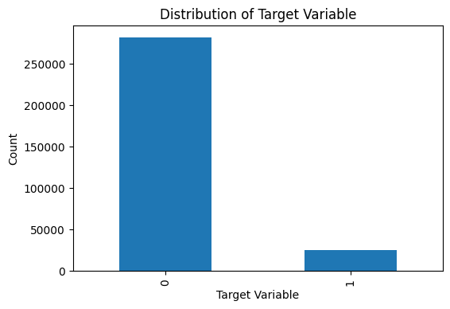

```python
#Value counts of the target variable
target_counts = train_data['TARGET'].value_counts()

#Set the figure size
plt.figure(figsize=(6, 4))

#Create the bar plot
target_counts.plot(kind='bar')

#Set the labels and title
plt.xlabel('Target Variable')
plt.ylabel('Count')
plt.title('Distribution of Target Variable')

#Show the plot
plt.show()
```

*Within our training and test datasets we see that the data is skewed to the target variable =0, so this may effect the analysis for the predictions. We then must oversample our datasets, so then we can have a more fair distribution of the target varaible outcomes and the datasets.*

```python
#Split the data into training and validation sets
y = train_data['TARGET']
X = train_data.drop('TARGET', axis=1)
X_train, X_val, y_train, y_val = train_test_split(X, y, test_size=0.2, random_state=42)

#Perform oversampling on the training set
oversampler = RandomOverSampler(random_state=42)
X_train_resampled, y_train_resampled = oversampler.fit_resample(X_train, y_train)
```

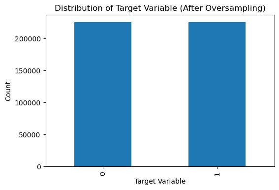

```python
#Calculate the count of each class in the resampled training set
target_counts_resampled = pd.Series(y_train_resampled).value_counts()

#Set the figure size
plt.figure(figsize=(6, 4))

#Create the bar plot
target_counts_resampled.plot(kind='bar')

#Set the labels and title
plt.xlabel('Target Variable')
plt.ylabel('Count')
plt.title('Distribution of Target Variable (After Oversampling)')

#Show the plot
plt.show()
```

*After oversampling, we see that there is a better and more fair distribution between the target variable of the customer defaulting and the customer not defaulting. This is going to be a lot better at predicting the outcomes when we conduct our modeling using machine learning on the datasets.*

### Hyperparameter Tuning

*When picking a search option for the boosted trees model, we first went with a grid search. To simply use a GridSearchCV function would take up too much time for the process to complete. To overcome this, we use the RamdomizedSearchCV rather than GridSearch to preserve on time and computation memory and still get an accurate model.*

```python
#Create an XGBoost classifier
xgb_model = xgb.XGBClassifier()

#Define the parameter distributions for randomized search
param_dist = {
    'n_estimators': randint(100, 500),
    'max_depth': randint(3, 10),
    'learning_rate': uniform(0.01, 0.1)
}

#Perform randomized search for hyperparameter tuning with increased iterations and cv folds
random_search = RandomizedSearchCV(estimator=xgb_model, param_distributions=param_dist, n_iter=5, cv=2, scoring='accuracy')
random_search.fit(X_train_resampled, y_train_resampled)
```

```
RandomizedSearchCV(cv=2,
                   estimator=XGBClassifier(base_score=None, booster=None,
                                           callbacks=None,
                                           colsample_bylevel=None,
                                           colsample_bynode=None,
                                           colsample_bytree=None,
                                           early_stopping_rounds=None,
                                           enable_categorical=False,
                                           eval_metric=None, feature_types=None,
                                           gamma=None, gpu_id=None,
                                           grow_policy=None,
                                           importance_type=None,
                                           interaction_constraints=None,
                                           learning_rate...
                                           predictor=None, random_state=None, ...),
                   n_iter=5,
                   param_distributions={'learning_rate': <scipy.stats._distn_infrastructure.rv_continuous_frozen object at 0x0000014F071B7460>,
                                        'max_depth': <scipy.stats._distn_infrastructure.rv_discrete_frozen object at 0x0000014F071B7CD0>,
                                        'n_estimators': <scipy.stats._distn_infrastructure.rv_discrete_frozen object at 0x0000014F405631F0>},
                   scoring='accuracy')
```

*This output tells us how we have used the hyper parameter while creating the Gradient Boosting model. We see that these hyper paramters were able to successfully execute while now being able to use our Gradient model for evaluation in the next few steps*

### Training the Model and Cross Validation

```python
#Get the best estimator from randomized search
best_xgb_model = random_search.best_estimator_
```

*We performed a x5 cross validation method to test the accuracy of the model. The results of that is below in the accuracy of the model section.*

```python
#Evaluate the model using cross-validation
cv_scores = cross_val_score(best_xgb_model, X_train_resampled, y_train_resampled, cv=5, scoring='accuracy')
```

```python
#Make predictions on the validation set
val_predictions = best_xgb_model.predict(X_val)
```

### Feature Importance

I ran this model many times trying to change it increase the accuracy. Each time the top feature importance fields would change slighly depending on the perimeters of the model. The top 5 important features of this final version include EXT_SOURCE_3, EXT_SOURCE_2, AMT_REQ_CREDIT_BUREAU_DAY, FLAG_EMP_PHONE and FLAG_DOCUMENT_3.

```python
#Feature importance
feature_importances = best_xgb_model.feature_importances_

#Create a DataFrame to store the feature importances
importance_df = pd.DataFrame({'Feature': X_train.columns, 'Importance': feature_importances})

#Sort the DataFrame by importance in descending order
importance_df = importance_df.sort_values('Importance', ascending=False)

#Display the top 10 most important features
print(importance_df.head(20))
```

```
                        Feature  Importance
28                 EXT_SOURCE_3    0.069916
27                 EXT_SOURCE_2    0.050373
55    AMT_REQ_CREDIT_BUREAU_DAY    0.040668
12               FLAG_EMP_PHONE    0.037057
35              FLAG_DOCUMENT_3    0.029822
48             FLAG_DOCUMENT_16    0.025261
19  REGION_RATING_CLIENT_W_CITY    0.023824
5               AMT_GOODS_PRICE    0.023529
54   AMT_REQ_CREDIT_BUREAU_HOUR    0.022048
24       REG_CITY_NOT_LIVE_CITY    0.020464
25       REG_CITY_NOT_WORK_CITY    0.019871
50             FLAG_DOCUMENT_18    0.019775
3                    AMT_CREDIT    0.019445
32     DEF_60_CNT_SOCIAL_CIRCLE    0.019247
4                   AMT_ANNUITY    0.018796
46             FLAG_DOCUMENT_14    0.018267
8                 DAYS_EMPLOYED    0.018109
31     OBS_60_CNT_SOCIAL_CIRCLE    0.017978
13              FLAG_WORK_PHONE    0.017963
7                    DAYS_BIRTH    0.017441
```

[figure not shown]

```python
#Visualize the feature importance

#Set the figure size
plt.figure(figsize=(10, 6))

#Create the bar plot
plt.bar(importance_df['Feature'], importance_df['Importance'])
plt.xticks(rotation='vertical')
plt.xlabel('Features')
plt.ylabel('Importance')
plt.title('Feature Importances')

#Adjust the spacing between the bars and the plot's edges
plt.tight_layout()

#Display the plot
plt.show()
```

*Within our Gradient Boost model we can see that the variables of EXT_SOURCE_3, EXT_SOURCE_2, AMT_REQ_CREDIT_BUREAU_DAY, FLAG_EMP_PHONE, and FLAG_DOCUMENT_3 are the top 5 most important variables in predicting if the customer will default. This tell us that it is most important to pay attention to the normalized score from external data source, Number of enquiries to Credit Bureau about the client one day before application, Did client provide work phone (1=YES, 0=NO), and Indicating if there is a third document provided by the client are the most important to predicting if the customer will default.*

### Accuracy of the Model

```python
#Calculate the AUC score
auc_score = roc_auc_score(y_val, val_predictions)
print("AUC Score:", auc_score)
```

```
AUC Score: 0.6688192795641691
```

*This model received a AUC score fo .6688 suggesting that this model has a fair level of predictive power. It is a moderate power of predicting if the customer will default or not. This represents that using the model will still give us better results rather than randomly guessing because the AUC is greater than .5.*

```python
#Print the cross-validation scores
print("Cross-validation scores:", cv_scores)
print("Mean Accuracy:", np.mean(cv_scores))
```

```
Cross-validation scores: [0.78187567 0.78186461 0.78562347 0.77866959 0.78151948]
Mean Accuracy: 0.7819105646456832
```

*Within each of the folds of the cross validation scores we see that each fold is highly accurate. The accuracy score measures the proportion of correctly classified instances. Meaning that within each fold there is about a 78% chance that the classifications are correct*

*The mean accuracy of 0.7819105646456832 means that on average the Cross Validation of the Gradient Boost Model got an average of 78.19% classifications correct. It is an average accuracy of 78.19%*

```python
#Create confusion matrix
confusion_mat = confusion_matrix(y_val, val_predictions)
print("Confusion Matrix:")
print(confusion_mat)
```

```
Confusion Matrix:
[[42898 13656]
 [ 2083  2866]]
```

- *True Negative (TN): The model predicted the negative class correctly, and the actual class was also negative. In this case, there are 42,898 instances where the model correctly predicted the negative class.*
- *False Positive (FP): The model predicted the positive class incorrectly, while the actual class was negative. Here, the model made an incorrect positive prediction in 13,656 instances.*
- *False Negative (FN): The model predicted the negative class incorrectly, while the actual class was positive. There are 2,083 instances where the model made an incorrect negative prediction.*
- *True Positive (TP): The model predicted the positive class correctly, and the actual class was also positive. In this case, the model made correct positive predictions in 2,866 instances.*

```python
#Evaluating confusion matrix values
TN, FP, FN, TP = confusion_mat.ravel()

#Calculate accuracy
accuracy = (TP + TN) / (TP + TN + FP + FN)

#Calculate precision
precision = TP / (TP + FP)

#Calculate recall
recall = TP / (TP + FN)

#Calculate F1-score
f1_score = 2 * (precision * recall) / (precision + recall)

# Print the metrics
print("Accuracy:", accuracy)
print("Precision:", precision)
print("Recall:", recall)
print("F1-score:", f1_score)
```

```
Accuracy: 0.7440937840430548
Precision: 0.17346568212080862
Recall: 0.5791068902808648
F1-score: 0.2669647431419124
```

*The accuracy score is 0.744, indicating that 74.4% of the predictions made by the model were correct. A precision score of 0.173 indicates that out of all the cases predicted as positive, only 17.3% were actually true positives. A recall score of 0.579 means that the model identified 57.9% of the actual positive cases.The F1-score is 0.267, which suggests that the model's overall performance is on the low side.*

### Prediction on the Test Set

```python
#Make predictions on the test set
test_predictions = best_xgb_model.predict(test_data)
```

```python
#Create a submission DataFrame
submission = pd.DataFrame({
    "SK_ID_CURR": test_data["SK_ID_CURR"],
    "TARGET": test_predictions
})

#Remove duplicate SK_ID_CURR values
submission = submission.drop_duplicates(subset="SK_ID_CURR", keep="first")

#Save the submission DataFrame to a CSV file
submission.to_csv("submission.csv", index=False)
```

## Recalling Training sets and Cross Validations For Next Model

*Here we have recalled our training and test sets that we established in the previous page. These are the sets that were used with our newly cleaned data and merged with other datasets. In this section we recall the sets already created by calling them and setting the same parameters after the cleaned data used.*

```python
# import pandas as pd
from sklearn.model_selection import train_test_split
from sklearn.model_selection import cross_val_score
from sklearn.ensemble import RandomForestClassifier
from sklearn.metrics import accuracy_score


y = train_data['TARGET']
X = train_data.drop('TARGET', axis=1)
X_train, X_val, y_train, y_val = train_test_split(X, y, test_size=0.2, random_state=42)
```

## Identifying the performance benchmark established by the majority class classifier.

```python
# Count the occurrences of each class
class_counts = y_train.value_counts()

# Identify the majority class
majority_class = class_counts.idxmax()

# Calculate the accuracy of the majority class classifier
accuracy_majority_class = class_counts[majority_class] / len(X_train)
print(accuracy_majority_class)
```

```
0.919205879483594
```

*This tells us the accuracy of the majority class classifier. The accuracy of the majority class classifier is approximately 0.9192, or 91.92%. Meaning that if we were to predict the majority class for all variables in the training dataset, we would be correct about 91.921% of the time.*

## Performing the data transformations needed throughout our algorithms

```python
from sklearn.preprocessing import StandardScaler, MinMaxScaler, OneHotEncoder
import numpy as np

# Concatenate training and validation datasets
X_train_val = np.concatenate((X_train, X_val), axis=0)

# Standardization
scaler = StandardScaler()
X_train_val_scaled = scaler.fit_transform(X_train_val)

# Normalization
normalizer = MinMaxScaler()
X_train_val_normalized = normalizer.fit_transform(X_train_val)

# One-Hot Encoding
encoder = OneHotEncoder()
X_train_val_encoded = encoder.fit_transform(X_train_val)
```

## Multiple Regression Models

### Fitting several different logistic regression models using different interactions

```python
import time
from sklearn.preprocessing import PolynomialFeatures
from sklearn.linear_model import LogisticRegression
from sklearn.metrics import accuracy_score, roc_auc_score

# Generate interaction terms
poly = PolynomialFeatures(interaction_only=True, include_bias=False)
start_time = time.time()
X_train_with_interactions = poly.fit_transform(X_train)
end_time = time.time()

# Fit logistic regression models with and without interaction terms
model_without_interactions = LogisticRegression()
model_without_interactions.fit(X_train, y_train)

model_with_interactions = LogisticRegression()
start_time_with_interactions = time.time()
model_with_interactions.fit(X_train_with_interactions, y_train)
end_time_with_interactions = time.time()

# Prepare validation data
start_time_val = time.time()
X_val_with_interactions = poly.transform(X_val)
end_time_val = time.time()

# Make predictions on the validation set
start_time_preds = time.time()
preds_without_interactions = model_without_interactions.predict(X_val)
probs_without_interactions = model_without_interactions.predict_proba(X_val)[:, 1]

preds_with_interactions = model_with_interactions.predict(X_val_with_interactions)
probs_with_interactions = model_with_interactions.predict_proba(X_val_with_interactions)[:, 1]
end_time_preds = time.time()

# Evaluate model performance
start_time_eval = time.time()
accuracy_without_interactions = accuracy_score(y_val, preds_without_interactions)
auc_without_interactions = roc_auc_score(y_val, probs_without_interactions)

accuracy_with_interactions = accuracy_score(y_val, preds_with_interactions)
auc_with_interactions = roc_auc_score(y_val, probs_with_interactions)
end_time_eval = time.time()

# Print the runtimes
print("Runtime for generating interaction terms:", end_time - start_time, "seconds")
print("Runtime for fitting model with interactions:", end_time_with_interactions - start_time_with_interactions, "seconds")
print("Runtime for preparing validation data:", end_time_val - start_time_val, "seconds")
print("Runtime for making predictions:", end_time_preds - start_time_preds, "seconds")
print("Runtime for evaluating model performance:", end_time_eval - start_time_eval, "seconds")

# Compare model performance
print("\nModel without interactions:")
print("Accuracy:", accuracy_without_interactions)
print("AUC:", auc_without_interactions)

print("\nModel with interactions:")
print("Accuracy:", accuracy_with_interactions)
print("AUC:", auc_with_interactions)
```

```
Runtime for generating interaction terms: 11.300916910171509 seconds
Runtime for fitting model with interactions: 18.78170418739319 seconds
Runtime for preparing validation data: 2.673457384109497 seconds
Runtime for making predictions: 1.056178331375122 seconds
Runtime for evaluating model performance: 0.1746351718902588 seconds

Model without interactions:
Accuracy: 0.9195161211648212
AUC: 0.6203350955928995

Model with interactions:
Accuracy: 0.9195323805342829
AUC: 0.5
```

*From our output of the logistic regression modeling, we see that the model without interactions had a accuracy of 91.9516% and an AUC of .62. The model with interactions has a accuracy of 91.9532% but an AUC of .5.*

*There may be a higher AUC within the model without interactions because there is less to consider in the effect that intereactions can have one the target variable. Although our AUC is lower for the model with interactions, this may because now we are looking at the bigger picture with all interactive varaibles and we are resulting in getting a higher accuracy of the logistic regresssion model when we include the interactions.*

### Attempting for the Up and Down Sampling for the Logistic Regression Model

```python
import time
from sklearn.linear_model import LogisticRegression
from sklearn.utils import resample
from sklearn.metrics import accuracy_score

# Analyze class distribution in the training set
class_counts = y_train.value_counts()
print("Class Distribution (Before):")
print(class_counts)

# Upsample the minority class
df_majority = X_train[y_train == 0]
df_minority = X_train[y_train == 1]

start_time_upsample = time.time()
df_minority_upsampled = resample(df_minority, replace=True, n_samples=len(df_majority), random_state=42)
X_train_upsampled = pd.concat([df_majority, df_minority_upsampled])
y_train_upsampled = pd.Series([0] * len(df_majority) + [1] * len(df_minority_upsampled))
end_time_upsample = time.time()

# Downsample the majority class
start_time_downsample = time.time()
df_majority_downsampled = resample(df_majority, replace=False, n_samples=len(df_minority), random_state=42)
X_train_downsampled = pd.concat([df_majority_downsampled, df_minority])
y_train_downsampled = pd.Series([0] * len(df_majority_downsampled) + [1] * len(df_minority))
end_time_downsample = time.time()

# Train and evaluate models on upsampled and downsampled data
model = LogisticRegression()  # Initialize the LogisticRegression model

# Train on upsampled data
start_time_train_upsampled = time.time()
model.fit(X_train_upsampled, y_train_upsampled)
y_pred_upsampled = model.predict(X_val)
accuracy_upsampled = accuracy_score(y_val, y_pred_upsampled)
end_time_train_upsampled = time.time()

# Train on downsampled data
start_time_train_downsampled = time.time()
model.fit(X_train_downsampled, y_train_downsampled)
y_pred_downsampled = model.predict(X_val)
accuracy_downsampled = accuracy_score(y_val, y_pred_downsampled)
end_time_train_downsampled = time.time()

# Compute predictions for original data
start_time_pred_original = time.time()
y_pred_original = model.predict(X_val)
accuracy_original = accuracy_score(y_val, y_pred_original)
end_time_pred_original = time.time()

# Print the runtimes
print("Upsampling Runtime:", end_time_upsample - start_time_upsample, "seconds")
print("Downsampling Runtime:", end_time_downsample - start_time_downsample, "seconds")
print("Upsampled Training Runtime:", end_time_train_upsampled - start_time_train_upsampled, "seconds")
print("Downsampled Training Runtime:", end_time_train_downsampled - start_time_train_downsampled, "seconds")
print("Original Prediction Runtime:", end_time_pred_original - start_time_pred_original, "seconds")

# Compare model performance
print("Accuracy (Original):", accuracy_original)
print("Accuracy (Upsampled):", accuracy_upsampled)
print("Accuracy (Downsampled):", accuracy_downsampled)
```

```
Class Distribution (Before):
0    226132
1     19876
Name: TARGET, dtype: int64
Upsampling Runtime: 1.366769790649414 seconds
Downsampling Runtime: 0.23794841766357422 seconds
Upsampled Training Runtime: 7.301072359085083 seconds
Downsampled Training Runtime: 0.6300501823425293 seconds
Original Prediction Runtime: 0.03173041343688965 seconds
Accuracy (Original): 0.5965237468090987
Accuracy (Upsampled): 0.5941986569760824
Accuracy (Downsampled): 0.5965237468090987
```

*When considering whether to up or downsample the dataset, we see that upsampling gives us the lowest accuracy within our modeling of only being 59.41% accurate in predicting for the target variable.*

*We see that the original and downsample of the logistic regression give us the same and higher accuracy of 59.65%. Because of this when we perform our hyper paramters and evaluations within the logistic regression model we are going to keep our original data rather than the up or down sampled versions of the data.*

### Hyper Parameter Tuning of the Logistic Regressions

```python
import time
from sklearn.model_selection import GridSearchCV
from sklearn.linear_model import LogisticRegression
from sklearn.metrics import accuracy_score

# Define the hyperparameters and their search space
param_grid = {
    'C': [0.1, 1.0, 10.0],
    'penalty': ['l1', 'l2'],
    'solver': ['liblinear']
}

# Initialize the model
model = LogisticRegression(random_state=42)

# Perform grid search with cross-validation
start_time = time.time()
grid_search = GridSearchCV(model, param_grid, cv=5, scoring='accuracy')
grid_search.fit(X_train, y_train)
end_time = time.time()

# Get the best hyperparameter values and model performance
best_params = grid_search.best_params_
best_score = grid_search.best_score_

# Train the model with the best hyperparameters
start_time_train = time.time()
best_model = LogisticRegression(**best_params, random_state=42)
best_model.fit(X_train, y_train)
end_time_train = time.time()

# Make predictions using the best model
start_time_pred = time.time()
y_pred = best_model.predict(X_val)
end_time_pred = time.time()

# Evaluate the model performance
start_time_eval = time.time()
accuracy = accuracy_score(y_val, y_pred)
end_time_eval = time.time()

# Print the runtimes
print("Grid Search Runtime:", end_time - start_time, "seconds")
print("Training Runtime:", end_time_train - start_time_train, "seconds")
print("Prediction Runtime:", end_time_pred - start_time_pred, "seconds")
print("Evaluation Runtime:", end_time_eval - start_time_eval, "seconds")

# Print the best hyperparameters and model performance
print("Best Hyperparameters:", best_params)
print("Best Score:", best_score)
print("Accuracy:", accuracy)
```

```
Grid Search Runtime: 364.85560846328735 seconds
Training Runtime: 4.806471347808838 seconds
Prediction Runtime: 0.051279544830322266 seconds
Evaluation Runtime: 0.0 seconds
Best Hyperparameters: {'C': 0.1, 'penalty': 'l2', 'solver': 'liblinear'}
Best Score: 0.9192018146332195
Accuracy: 0.9195161211648212
```

*After using hyper parameters, we see a couple of interesting observations. The first of which is that this process takes a long time to complete. Taking about 6 minutes to compute.*

*Within the best hyperparameters for modeling we see that*

- *Because C is .1, suggests a moderately strong regularization is preferred by the model*
- *The penalty being of L2 means that Ridge Regularization will give us our best results*
- *Solver being assigned as liblinear means that this solver is suitable for small to medium size datasets and supports L1 and L2 penalities*

*With the best score being 0.9192018146332195 this means that at the cross validations the mean of the accuracies is 0.9192018146332195. Meaning, that on average at the best paramters the model was performing highly well.*

*With best accuracy of 0.9195161211648212 meaning that in the best case scenario this model will be 91.95% accurate when predicting for the target variable when against unknown datasets.*

### Model performance of Best Logistic Regression Model

```python
import time
from sklearn.metrics import classification_report, roc_auc_score

# Train set performance
start_time_train = time.time()
train_pred = best_model.predict(X_train)
train_auc = roc_auc_score(y_train, train_pred)
end_time_train = time.time()

# Print train set performance and runtime
print("Train Set Performance:")
print("AUC:", train_auc)
print(classification_report(y_train, train_pred))
print("Train Set Runtime:", end_time_train - start_time_train, "seconds")

# Test set performance
start_time_test = time.time()
test_pred = best_model.predict(X_val)
test_auc = roc_auc_score(y_val, test_pred)
end_time_test = time.time()

# Print test set performance and runtime
print("Test Set Performance:")
print("AUC:", test_auc)
print(classification_report(y_val, test_pred))
print("Test Set Runtime:", end_time_test - start_time_test, "seconds")
```

```
Train Set Performance:
AUC: 0.4999977889020572
              precision    recall  f1-score   support

           0       0.92      1.00      0.96    226132
           1       0.00      0.00      0.00     19876

    accuracy                           0.92    246008
   macro avg       0.46      0.50      0.48    246008
weighted avg       0.84      0.92      0.88    246008

Train Set Runtime: 0.22581863403320312 seconds
Test Set Performance:
AUC: 0.49999115889238605
              precision    recall  f1-score   support

           0       0.92      1.00      0.96     56554
           1       0.00      0.00      0.00      4949

    accuracy                           0.92     61503
   macro avg       0.46      0.50      0.48     61503
weighted avg       0.85      0.92      0.88     61503

Test Set Runtime: 0.03416752815246582 seconds
```

*Under the best parameters set for the Logistic Regression Modeling*

*The Train Set*

- *Has an AUC of 0.4999977889020572. Meaning that the models predictive powers seem to be pretty close to random and the discriminative power of the model are fairly low.*
- *The precision, recall, and F1 score for the majority class of 0 (Those who do not default) are all very high meaning that the model performs well in identifying the majority class*
- *However the precision, recall, and F1 score for the minority class of 1 (Those who do default) are very low at 0. Meaning that it is difficult for the model to predict those who will default.
- *This train set does give a 92% accuracy though, largely due to its ability to correctly predict the majority class of those who do not default*

*The Test Set*

- *The evaluation of the Test set performs almost identical to that of the train dataset.*

*While the AUC may be lower and may suggest low discrimative power in classification, we do know that this model does provide a sense of accuracy when seeing who is a safe borrower.*

### Features of the Best Logistic Model

```python
import time
from sklearn.linear_model import LogisticRegression
import pandas as pd

# Set pandas display options
pd.set_option('display.float_format', lambda x: '%.8f' % x)

# Get the feature coefficients and their corresponding names
start_time = time.time()
coefficients = best_model.coef_[0]
feature_names = X_train.columns
end_time = time.time()

# Create a DataFrame to store the coefficients and feature names
start_time_df = time.time()
coefficients_df = pd.DataFrame({'Feature': feature_names, 'Coefficient': coefficients})
end_time_df = time.time()

# Sort the DataFrame by coefficient magnitude in descending order
start_time_sort = time.time()
coefficients_df = coefficients_df.sort_values('Coefficient', ascending=False)
end_time_sort = time.time()

# Display the coefficients and their impact on the target variable
print(coefficients_df.head(10))

# Print the runtimes
print("Runtime for retrieving coefficients:", end_time - start_time, "seconds")
print("Runtime for creating DataFrame:", end_time_df - start_time_df, "seconds")
print("Runtime for sorting DataFrame:", end_time_sort - start_time_sort, "seconds")
```

```
                       Feature  Coefficient
33      DAYS_LAST_PHONE_CHANGE   0.00021637
10             DAYS_ID_PUBLISH   0.00009348
7                   DAYS_BIRTH   0.00008404
9            DAYS_REGISTRATION   0.00002685
4                  AMT_ANNUITY   0.00000776
3                   AMT_CREDIT   0.00000310
61          CREDIT_DAY_OVERDUE   0.00000259
8                DAYS_EMPLOYED   0.00000052
59  AMT_REQ_CREDIT_BUREAU_YEAR   0.00000048
60                      SK_DPD   0.00000025
Runtime for retrieving coefficients: 0.0 seconds
Runtime for creating DataFrame: 0.024721384048461914 seconds
Runtime for sorting DataFrame: 0.009205102920532227 seconds
```

- *Number of days since the clients last owned phone*
- *Number of days since the client changed their ID info*
- *Age in days of the client*
- *Number of days before the application the client change their registration*
- *Loan annuity*
- *Credit amount of the loan*
- *Number of days past due on CB credit at the time of application for related loan*
- *Days before the application the person started current employment*
- *Number of enquiries to Credit Bureau about the client one year*
- *DPD (Days past due) during the month on the previous credit*

### Prediction on the Test Set

```python
#Make predictions on the test set
test_predictions = best_model.predict(test_data)
```

```python
#Create a submission DataFrame
submission = pd.DataFrame({
    "SK_ID_CURR": test_data["SK_ID_CURR"],
    "TARGET": test_predictions
})

#Remove duplicate SK_ID_CURR values
submission = submission.drop_duplicates(subset="SK_ID_CURR", keep="first")

#Save the submission DataFrame to a CSV file
submission.to_csv("submission_log2.csv", index=False)
```

*When we put this into Kaggle, we get a score of .5 While this may not be as high as anticipated, we see above the the accuracy of the model is much higher than that of the AUC even within the best hyper parameters.*

## Random Forest Classification Model

### Creating the Random Forest Classification and printing the Accuracy and AUC of the Model

```python
import time
from sklearn.ensemble import RandomForestClassifier
from sklearn.metrics import accuracy_score, roc_auc_score

# Fit Random Forest model
start_time_fit = time.time()
rf_model = RandomForestClassifier()
rf_model.fit(X_train, y_train)
end_time_fit = time.time()

# Make predictions with Random Forest model
start_time_pred = time.time()
rf_preds = rf_model.predict(X_val)
rf_probs = rf_model.predict_proba(X_val)[:, 1]
end_time_pred = time.time()

# Evaluate Random Forest model performance
start_time_eval = time.time()
rf_accuracy = accuracy_score(y_val, rf_preds)
rf_auc = roc_auc_score(y_val, rf_probs)
end_time_eval = time.time()

# Print the runtimes
print("Fit Runtime:", end_time_fit - start_time_fit, "seconds")
print("Prediction Runtime:", end_time_pred - start_time_pred, "seconds")
print("Evaluation Runtime:", end_time_eval - start_time_eval, "seconds")

# Compare model performance
print("Random Forest Model:")
print("Accuracy:", rf_accuracy)
print("AUC:", rf_auc)
```

```
Fit Runtime: 147.61922216415405 seconds
Prediction Runtime: 4.936388731002808 seconds
Evaluation Runtime: 0.02080988883972168 seconds
Random Forest Model:
Accuracy: 0.9196136773815912
AUC: 0.7069750901140923
```

### Attempting for the Up and Down Sampling for the Random Forest Model

```python
import time
from sklearn.ensemble import RandomForestClassifier
from sklearn.metrics import accuracy_score
from sklearn.utils import resample

# Analyze class distribution in the training set
start_time_dist = time.time()
class_counts = y_train.value_counts()
end_time_dist = time.time()

print("Class Distribution (Before):")
print(class_counts)

# Upsample the minority class
start_time_upsample = time.time()
df_majority = X_train[y_train == 0]
df_minority = X_train[y_train == 1]

df_minority_upsampled = resample(df_minority, replace=True, n_samples=len(df_majority), random_state=42)

X_train_upsampled = pd.concat([df_majority, df_minority_upsampled])
y_train_upsampled = pd.Series([0] * len(df_majority) + [1] * len(df_minority_upsampled))
end_time_upsample = time.time()

# Downsample the majority class
start_time_downsample = time.time()
df_majority_downsampled = resample(df_majority, replace=False, n_samples=len(df_minority), random_state=42)

X_train_downsampled = pd.concat([df_majority_downsampled, df_minority])
y_train_downsampled = pd.Series([0] * len(df_majority_downsampled) + [1] * len(df_minority))
end_time_downsample = time.time()

# Train and evaluate models on upsampled and downsampled data
start_time_train = time.time()
model = RandomForestClassifier()  # Initialize the Random Forest model

# Train on upsampled data
model.fit(X_train_upsampled, y_train_upsampled)
y_pred_upsampled = model.predict(X_val)
accuracy_upsampled = accuracy_score(y_val, y_pred_upsampled)

# Train on downsampled data
model.fit(X_train_downsampled, y_train_downsampled)
y_pred_downsampled = model.predict(X_val)
accuracy_downsampled = accuracy_score(y_val, y_pred_downsampled)
end_time_train = time.time()

# Compute predictions for original data
start_time_pred = time.time()
y_pred_original = model.predict(X_val)
accuracy_original = accuracy_score(y_val, y_pred_original)
end_time_pred = time.time()

# Compare model performance
print("Accuracy (Original):", accuracy_original)
print("Accuracy (Upsampled):", accuracy_upsampled)
print("Accuracy (Downsampled):", accuracy_downsampled)

# Print the runtimes
print("Class Distribution Runtime:", end_time_dist - start_time_dist, "seconds")
print("Upsampling Runtime:", end_time_upsample - start_time_upsample, "seconds")
print("Downsampling Runtime:", end_time_downsample - start_time_downsample, "seconds")
print("Training Runtime:", end_time_train - start_time_train, "seconds")
print("Prediction Runtime:", end_time_pred - start_time_pred, "seconds")
```

```
Class Distribution (Before):
0    226132
1     19876
Name: TARGET, dtype: int64
Accuracy (Original): 0.6793164561078321
Accuracy (Upsampled): 0.9196299367510528
Accuracy (Downsampled): 0.6793164561078321
Class Distribution Runtime: 0.013184785842895508 seconds
Upsampling Runtime: 0.5757849216461182 seconds
Downsampling Runtime: 0.07246971130371094 seconds
Training Runtime: 213.34045934677124 seconds
Prediction Runtime: 1.3933310508728027 seconds
```

### Hyper Parameters

```python
import time
from sklearn.model_selection import RandomizedSearchCV
from sklearn.ensemble import RandomForestClassifier
from sklearn.metrics import accuracy_score

# Define the hyperparameters and their search space
param_grid = {
    'n_estimators': [100, 200],
    'max_depth': [None, 5],
    'min_samples_split': [2, 5],
    'min_samples_leaf': [1, 2]
}

# Initialize the model
model = RandomForestClassifier(random_state=42)

# Perform randomized search with cross-validation
start_time_search = time.time()
# CV 2 was set here rather than 5 because the CV 5 took too much time. Longer than 8 hours. n_iter = 5
# was also set to make the process go faster
random_search = RandomizedSearchCV(model, param_distributions=param_grid, n_iter=5, cv=2, scoring='accuracy')
# Because our UpSampling had a better accuracy, we are using that here rather than the original
random_search.fit(X_train_upsampled, y_train_upsampled)
end_time_search = time.time()

# Get the best hyperparameter values and model performance
best_params = random_search.best_params_
best_score = random_search.best_score_

# Train the model with the best hyperparameters
start_time_train = time.time()
best_model = RandomForestClassifier(**best_params, random_state=42)
best_model.fit(X_train_upsampled, y_train_upsampled)
end_time_train = time.time()

# Make predictions using the best model
start_time_pred = time.time()
y_pred = best_model.predict(X_val)
end_time_pred = time.time()

# Evaluate the model performance
start_time_eval = time.time()
accuracy = accuracy_score(y_val, y_pred)
end_time_eval = time.time()

# Print the best hyperparameters and model performance
print("Best Hyperparameters:", best_params)
print("Best Score:", best_score)
print("Accuracy:", accuracy)

# Print the runtimes
print("Randomized Search Runtime:", end_time_search - start_time_search, "seconds")
print("Training Runtime:", end_time_train - start_time_train, "seconds")
print("Prediction Runtime:", end_time_pred - start_time_pred, "seconds")
print("Evaluation Runtime:", end_time_eval - start_time_eval, "seconds")
```

```
Best Hyperparameters: {'n_estimators': 100, 'min_samples_split': 2, 'min_samples_leaf': 1, 'max_depth': None}
Best Score: 0.9900522703553676
Accuracy: 0.9194185649480513
Randomized Search Runtime: 652.6474483013153 seconds
Training Runtime: 191.16876101493835 seconds
Prediction Runtime: 2.427534341812134 seconds
Evaluation Runtime: 0.008106470108032227 seconds
```

*After using hyper parameters, we see a couple of interesting observations. The first of which is that this process takes a long time to complete. Taking about 14 minutes to compute.*

*Within the best hyperparameters for modeling we see that*

- *Because n_estimators is 100 this means that at the best model, there will be 100 decision trees.*
- *min_samples_split tells us the minimum number of samples required to split into a node. The best is 2. Meaning a node is only split if it contains at least 2 samples*
- *min_samples_leaf is the minimum number of samples required to be at a leaf node. The best value is 1, indicating that a leaf node can have as few as 1 sample.*
- *max_depth is the maximum depth of the tree. The best value is None, which means there is no maximum depth limit, and the tree will grow until all leaves are pure or until all leaves contain a minimum number of samples.*

*With the best score being 0.9900522703553676 meaning that the best score that can be achieved within the model is about .99. A near perfect score. Meaning that the best Random Forest model acheived an average accuracy of 99% during cross validation within the search. This means that the model performs extremely well.*

*With best accuracy of 0.9194185649480513 meaning that in the best case scenario this model will be 91.94% accurate when predicting for the target variable when against unknown datasets.*

### Evaluating the Best Model Performance of the Random Classification

```python
import time
from sklearn.metrics import classification_report, roc_auc_score

# Train set performance
start_time_train = time.time()
train_pred = best_model.predict(X_train)
train_auc = roc_auc_score(y_train, train_pred)
end_time_train = time.time()

print("Train Set Performance:")
print("AUC:", train_auc)
print(classification_report(y_train, train_pred))

# Test set performance
start_time_test = time.time()
test_pred = best_model.predict(X_val)
test_auc = roc_auc_score(y_val, test_pred)
end_time_test = time.time()

print("Test Set Performance:")
print("AUC:", test_auc)
print(classification_report(y_val, test_pred))

# Print the runtimes
print("Training Runtime:", end_time_train - start_time_train, "seconds")
print("Testing Runtime:", end_time_test - start_time_test, "seconds")
```

```
Train Set Performance:
AUC: 1.0
              precision    recall  f1-score   support

           0       1.00      1.00      1.00    226132
           1       1.00      1.00      1.00     19876

    accuracy                           1.00    246008
   macro avg       1.00      1.00      1.00    246008
weighted avg       1.00      1.00      1.00    246008

Test Set Performance:
AUC: 0.507036696323935
              precision    recall  f1-score   support

           0       0.92      1.00      0.96     56554
           1       0.48      0.02      0.03      4949

    accuracy                           0.92     61503
   macro avg       0.70      0.51      0.49     61503
weighted avg       0.88      0.92      0.88     61503

Training Runtime: 9.18987774848938 seconds
Testing Runtime: 2.0379745960235596 seconds
```

*Under the best parameters set for the Random Forest Modeling*

*The Test Set*

- *AUC of AUC: 0.507036696323935. This shows us that within the test set, the model does have a discrimatory power, but it is relevatively low.*
- *The precision, recall, and F1 score are .92, 1.00, and .96 when the class of 0 (Those who are save borrowers). This means that the model predicts the class of 0 quite well.*
- *The precision, recall, and F1 score are .48, 0.02, and 0.03 when the class of 1 (Those who are NOT save borrowers). This means that the model predicts the class of 1 poorly.*
- *We see that because of the macro average and the weighted average they are unbalanced between the classes. This may be why the model is better at predicitng for class 0 than 1.*
- *The accuracy is 92% which again shows us that this model is accurate most often when predicting for the majority class of 0 , but not for the class of 1.*

### Features of the Best Random Forest Classification Model

```python
import time
# Feature importance
start_time = time.time()
feature_importances = best_model.feature_importances_

# Create a DataFrame to store the feature importances
importance_df = pd.DataFrame({'Feature': X_train.columns, 'Importance': feature_importances})

# Sort the DataFrame by importance in descending order
importance_df = importance_df.sort_values('Importance', ascending=False)

# Display the top 10 most important features
print(importance_df.head(10))
end_time = time.time()

# Print the runtime
print("Runtime:", end_time - start_time, "seconds")
```

```
                   Feature  Importance
27            EXT_SOURCE_2  0.09877625
28            EXT_SOURCE_3  0.09503074
7               DAYS_BIRTH  0.05982140
10         DAYS_ID_PUBLISH  0.05542707
4              AMT_ANNUITY  0.05442446
9        DAYS_REGISTRATION  0.05414072
8            DAYS_EMPLOYED  0.05385393
33  DAYS_LAST_PHONE_CHANGE  0.05312109
0               SK_ID_CURR  0.05280328
3               AMT_CREDIT  0.04984712
Runtime: 0.11169624328613281 seconds
```

*From this output, we learn that the top 10 most important features when seeing if someone is safe to lend money to are based on*

- *Normalized score from external data source*
- *Client's age in days at the time of application*
- *How many days before the application did client change the identity document*
- *Loan annuity*
- *How many days before the application did client change their registration*
- *How many days before the application the person started current employment*
- *Number of days since the client last changed their phone number*
- *ID of loan in our sample*
- *Credit amount of the loan*

### Prediction on the Test Set

```python
#Make predictions on the test set
test_predictions = best_model.predict(test_data)
```

```python
#Create a submission DataFrame
submission = pd.DataFrame({
    "SK_ID_CURR": test_data["SK_ID_CURR"],
    "TARGET": test_predictions
})

#Remove duplicate SK_ID_CURR values
submission = submission.drop_duplicates(subset="SK_ID_CURR", keep="first")

#Save the submission DataFrame to a CSV file
submission.to_csv("submission_randomforest3.csv", index=False)
```

*After putting this model into Kaggle, we see that we get a Kaggle score of .50195. This score may be different from our otherwise stronger AUC and Accuracy scores shown by the model previously because of the different ways that Kaggle examines the scores vs how the AUC parameters are evaluated amongst the data.*

## Ensemble Model

### Creating the Ensembel Model with the RandomForest, Logistic Regression, and Gradient Boosting Models

```python
import time
from sklearn.ensemble import VotingClassifier
from sklearn.model_selection import cross_val_score

# Initialize individual models
model1 = RandomForestClassifier()
model2 = LogisticRegression()
model3 = GradientBoostingClassifier()

# Evaluate individual models using cross-validation
start_time_cv = time.time()
model1_scores = cross_val_score(model1, X_train, y_train, cv=2, scoring='accuracy')
model2_scores = cross_val_score(model2, X_train, y_train, cv=2, scoring='accuracy')
model3_scores = cross_val_score(model3, X_train, y_train, cv=2, scoring='accuracy')
end_time_cv = time.time()

# Create the ensemble model
ensemble_model = VotingClassifier(estimators=[('model1', model1), ('model2', model2), ('model3', model3)])

# Evaluate ensemble model using cross-validation
start_time_ensemble_cv = time.time()
ensemble_scores = cross_val_score(ensemble_model, X_train, y_train, cv=5, scoring='accuracy')
end_time_ensemble_cv = time.time()

# Fit the ensemble model on the entire training set
start_time_fit = time.time()
ensemble_model.fit(X_train, y_train)
end_time_fit = time.time()

# Make predictions with the ensemble model
start_time_preds = time.time()
ensemble_preds = ensemble_model.predict(X_val)
end_time_preds = time.time()

# Calculate ensemble model accuracy
start_time_accuracy = time.time()
# Calculate accuracy for each individual model
model1_accuracy = np.mean(model1_scores)
model2_accuracy = np.mean(model2_scores)
model3_accuracy = np.mean(model3_scores)
ensemble_accuracy = accuracy_score(y_val, ensemble_preds)
end_time_accuracy = time.time()

# Print individual models and ensemble model performance
print("Individual Random Forrest Classifier Accuracy:", model1_accuracy)
print("Individual Logistic Regression Accuracy:", model2_accuracy)
print("Individual Gradient Boosting Classifier Accuracy:", model3_accuracy)
print("Ensemble Model Accuracy:", ensemble_accuracy)
print("Ensemble Model Cross-Validation Scores:", ensemble_scores)

# Print the runtimes
print("Cross-Validation Runtime:", end_time_cv - start_time_cv, "seconds")
print("Ensemble Cross-Validation Runtime:", end_time_ensemble_cv - start_time_ensemble_cv, "seconds")
print("Fit Runtime:", end_time_fit - start_time_fit, "seconds")
print("Prediction Runtime:", end_time_preds - start_time_preds, "seconds")
print("Accuracy Calculation Runtime:", end_time_accuracy - start_time_accuracy, "seconds")
```

```
Individual Random Forrest Classifier Accuracy: 0.9193278267373419
Individual Logistic Regression Accuracy: 0.9192018145751357
Individual Gradient Boosting Classifier Accuracy: 0.9192790478358427
Ensemble Model Accuracy: 0.9196299367510528
Ensemble Model Cross-Validation Scores: [0.9192919  0.91925125 0.91925125 0.91931058 0.91918863]
Cross-Validation Runtime: 275.05734634399414 seconds
Ensemble Cross-Validation Runtime: 1118.3136358261108 seconds
Fit Runtime: 297.7979905605316 seconds
Prediction Runtime: 2.6046464443206787 seconds
Accuracy Calculation Runtime: 0.007262468338012695 seconds
```

*When we perform the ensemble model of all of the logistic Regression, Random Forest, and Gradient Boosting Models we can see that the Ensemble Model has an accuracy of 0.9196299367510528 or 91.96% accurate when predicting for the outcome of whether the customer will be a safe borrower or not.*

*This is an impressively high accuracy for the begining of the model, so let us see if we can take it one step further by sampling up or down with the dataset.*

### Up and Down Sampling

```python
import time
from sklearn.metrics import accuracy_score
from sklearn.utils import resample

# Analyze class distribution in the training set
class_counts = y_train.value_counts()
print("Class Distribution (Before):")
print(class_counts)

# Upsample the minority class
df_majority = X_train[y_train == 0]
df_minority = X_train[y_train == 1]

df_minority_upsampled = resample(df_minority, replace=True, n_samples=len(df_majority), random_state=42)

X_train_upsampled = pd.concat([df_majority, df_minority_upsampled])
y_train_upsampled = pd.Series([0] * len(df_majority) + [1] * len(df_minority_upsampled))

# Downsample the majority class
df_majority_downsampled = resample(df_majority, replace=False, n_samples=len(df_minority), random_state=42)

X_train_downsampled = pd.concat([df_majority_downsampled, df_minority])
y_train_downsampled = pd.Series([0] * len(df_majority_downsampled) + [1] * len(df_minority))

# Train and evaluate models on upsampled and downsampled data
model = ensemble_model  # Initialize the Ensemble model created

# Train on upsampled data
start_time_upsampled = time.time()
model.fit(X_train_upsampled, y_train_upsampled)
end_time_upsampled = time.time()

# Make predictions on upsampled data
start_time_pred_upsampled = time.time()
y_pred_upsampled = model.predict(X_val)
end_time_pred_upsampled = time.time()

# Calculate accuracy on upsampled data
start_time_accuracy_upsampled = time.time()
accuracy_upsampled = accuracy_score(y_val, y_pred_upsampled)
end_time_accuracy_upsampled = time.time()

# Train on downsampled data
start_time_downsampled = time.time()
model.fit(X_train_downsampled, y_train_downsampled)
end_time_downsampled = time.time()

# Make predictions on downsampled data
start_time_pred_downsampled = time.time()
y_pred_downsampled = model.predict(X_val)
end_time_pred_downsampled = time.time()

# Calculate accuracy on downsampled data
start_time_accuracy_downsampled = time.time()
accuracy_downsampled = accuracy_score(y_val, y_pred_downsampled)
end_time_accuracy_downsampled = time.time()

# Compute predictions for original data
start_time_pred_original = time.time()
y_pred_original = model.predict(X_val)
end_time_pred_original = time.time()

# Calculate accuracy on original data
start_time_accuracy_original = time.time()
accuracy_original = accuracy_score(y_val, y_pred_original)
end_time_accuracy_original = time.time()

# Print model performance and runtimes
print("Accuracy (Original):", accuracy_original)
print("Accuracy (Upsampled):", accuracy_upsampled)
print("Accuracy (Downsampled):", accuracy_downsampled)

print("Upsampled Training Runtime:", end_time_upsampled - start_time_upsampled, "seconds")
print("Upsampled Prediction Runtime:", end_time_pred_upsampled - start_time_pred_upsampled, "seconds")
print("Upsampled Accuracy Calculation Runtime:", end_time_accuracy_upsampled - start_time_accuracy_upsampled, "seconds")

print("Downsampled Training Runtime:", end_time_downsampled - start_time_downsampled, "seconds")
print("Downsampled Prediction Runtime:", end_time_pred_downsampled - start_time_pred_downsampled, "seconds")
print("Downsampled Accuracy Calculation Runtime:", end_time_accuracy_downsampled - start_time_accuracy_downsampled, "seconds")

print("Original Prediction Runtime:", end_time_pred_original - start_time_pred_original, "seconds")
print("Original Accuracy Calculation Runtime:", end_time_accuracy_original - start_time_accuracy_original, "seconds")
```

```
Class Distribution (Before):
0    226132
1     19876
Name: TARGET, dtype: int64
Accuracy (Original): 0.6838203014487099
Accuracy (Upsampled): 0.7884493439344422
Accuracy (Downsampled): 0.6838203014487099
Upsampled Training Runtime: 454.61707830429077 seconds
Upsampled Prediction Runtime: 2.442786931991577 seconds
Upsampled Accuracy Calculation Runtime: 0.017435789108276367 seconds
Downsampled Training Runtime: 47.265679121017456 seconds
Downsampled Prediction Runtime: 2.351642370223999 seconds
Downsampled Accuracy Calculation Runtime: 0.004544496536254883 seconds
Original Prediction Runtime: 1.99517822265625 seconds
Original Accuracy Calculation Runtime: 0.008304834365844727 seconds
```

*Within our Ensemble Model we see that the method that has the highest accuracy is when we use the Upsample dataset with an accuracy of 0.7884493439344422 or 78.84%. The original and downsampled dataset have an accuracy of 0.6838203014487099 or 68.38%. The Upsample data will now be used within our hyper parameters and evaluation of the model and features.*

### Hyper Parameters

```python
import time
from tqdm import tqdm
from sklearn.model_selection import GridSearchCV
from sklearn.ensemble import RandomForestClassifier, VotingClassifier
from sklearn.linear_model import LogisticRegression
from sklearn.ensemble import GradientBoostingClassifier
from sklearn.metrics import accuracy_score
from sklearn.model_selection import train_test_split

# Define the hyperparameters and their search space
param_grid = {
    'model1__n_estimators': [50, 100],
    'model1__max_depth': [None],
    'model1__min_samples_split': [2],
    'model1__min_samples_leaf': [1],
    'model2__C': [1.0],
    'model2__penalty': ['l2'],
    'model2__solver': ['liblinear']
}

# Reduce the number of cross-validation folds
cv = 2

# Split the training data into a smaller subset
X_train_subset, _, y_train_subset, _ = train_test_split(X_train_upsampled, y_train_upsampled, train_size=0.5, random_state=42)

# Initialize base estimators
model1 = RandomForestClassifier(n_estimators=50, random_state=42)  # Reduced number of estimators
model2 = LogisticRegression(random_state=42, max_iter=1000)  # Increased max_iter for faster convergence
model3 = GradientBoostingClassifier(random_state=42)

# Initialize ensemble model
ensemble_model = VotingClassifier(estimators=[('model1', model1),
                                              ('model2', model2),
                                              ('model3', model3)])

# Perform grid search with cross-validation
start_time_search = time.time()
grid_search = GridSearchCV(ensemble_model, param_grid, cv=cv, scoring='accuracy', n_jobs=-1)

# Wrap the grid search with tqdm and display progress and ETA
with tqdm(total=cv * len(grid_search.param_grid), ncols=80,
          bar_format='{l_bar}{bar}| {n_fmt}/{total_fmt} [{elapsed}<{remaining}, {rate_fmt}{postfix}], ETA: {remaining_s:.0f}s') as pbar:
    grid_search.fit(X_train_subset, y_train_subset)
    pbar.update(cv * len(grid_search.param_grid))  # Manually update progress bar to completion

end_time_search = time.time()

# Get the best hyperparameter values and model performance
best_params = grid_search.best_params_
best_score = grid_search.best_score_

# Train the model with the best hyperparameters
best_rf_params = {k.replace('model1__', ''): v for k, v in best_params.items() if k.startswith('model1__')}
best_lr_params = {k.replace('model2__', ''): v for k, v in best_params.items() if k.startswith('model2__')}
best_model = VotingClassifier(estimators=[('model1', RandomForestClassifier(**best_rf_params, random_state=42)),
                                          ('model2', LogisticRegression(**best_lr_params, random_state=42, max_iter=1000)),
                                          ('model3', GradientBoostingClassifier(**best_rf_params, random_state=42))])

# Wrap the fitting process with tqdm and display progress and ETA
with tqdm(total=len(X_train_upsampled), ncols=80,
          bar_format='{l_bar}{bar}| {n_fmt}/{total_fmt} [{elapsed}<{remaining}, {rate_fmt}{postfix}], ETA: {remaining_s:.0f}s') as pbar:
    best_model.fit(X_train_upsampled, y_train_upsampled)
    pbar.update(len(X_train_upsampled))  # Manually update progress bar to completion

# Make predictions using the best model
start_time_pred = time.time()
y_pred = best_model.predict(X_val)
end_time_pred = time.time()

# Evaluate the model performance
start_time_accuracy = time.time()
accuracy = accuracy_score(y_val, y_pred)
end_time_accuracy = time.time()

# Print the best hyperparameters and model performance
print("Best Hyperparameters:", best_params)
print("Best Score:", best_score)
print("Accuracy:", accuracy)

# Print the runtimes
print("Grid Search Runtime:", end_time_search - start_time_search, "seconds")
print("Fit Runtime:", end_time_pred - start_time_pred, "seconds")
print("Prediction Runtime:", end_time_pred - start_time_pred, "seconds")
print("Accuracy Calculation Runtime:", end_time_accuracy - start_time_accuracy, "seconds")
```

```
Best Hyperparameters: {'model1__max_depth': None, 'model1__min_samples_leaf': 1, 'model1__min_samples_split': 2, 'model1__n_estimators': 100, 'model2__C': 1.0, 'model2__penalty': 'l2', 'model2__solver': 'liblinear'}
Best Score: 0.7919622167583535
Accuracy: 0.890493146675772
Grid Search Runtime: 459.12626457214355 seconds
Fit Runtime: 4.412505865097046 seconds
Prediction Runtime: 4.412505865097046 seconds
Accuracy Calculation Runtime: 0.021256446838378906 seconds
```

*After using hyper parameters, we see a couple of interesting observations. The first of which is that this process takes a long time to complete. Taking about 10 minutes to compute.*

*Within the best hyperparameters for modeling we see that*

- **model1__max_depth: In our scenario, it is set to None, meaning that there is no maximum depth limit.**
- **model1__min_samples_leaf: Here, it is set to 1, meaning each leaf node should have at least one sample.**
- **model1__min_samples_split: It is set to 2, indicating that a node must have at least 2 samples to be split. It may have more, but it must be a minimum of 2.**
- **model1__n_estimators: The best value found during the grid search is 100. This means that it takes about 100 decision trees to come up with the best parameter of the model.**
- **model2__C: This is used for the combination of the Logisitic Regtression within our model. The best value is 1.**
- **model2__penalty: The best choice is l2, which refers to ridge regularization.This ridge regularization may have also been thrown off because of the parameters set to reduce computation time and capacity.**
- **model2__solver: The best choice is liblinear, which is suitable for small datasets. This means that this model is going to have the best results when performed on small or medium datasets, rather than a large one.**

*With best accuracy of 0.890493146675772 meaning that in the best case scenario this model will be having the proportion of correct classifications with an unkown dataset of about .89 correct classifications. This means that at the best this model will still classify about .89 of the dataset correctly.*

### Evaluating the Best of the Ensemble Model

```python
import time
from sklearn.metrics import classification_report, roc_auc_score

# Train set performance
start_time_train = time.time()
train_pred = best_model.predict(X_train)
train_auc = roc_auc_score(y_train, train_pred)
end_time_train = time.time()

# Print train set performance and runtime
print("Train Set Performance:")
print("AUC:", train_auc)
print(classification_report(y_train, train_pred))
print("Train Set Performance Runtime:", end_time_train - start_time_train, "seconds")

# Test set performance
start_time_test = time.time()
test_pred = best_model.predict(X_val)
test_auc = roc_auc_score(y_val, test_pred)
end_time_test = time.time()

# Print test set performance and runtime
print("Test Set Performance:")
print("AUC:", test_auc)
print(classification_report(y_val, test_pred))
print("Test Set Performance Runtime:", end_time_test - start_time_test, "seconds")
```

```
Train Set Performance:
AUC: 1.0
              precision    recall  f1-score   support

           0       1.00      1.00      1.00    226132
           1       1.00      1.00      1.00     19876

    accuracy                           1.00    246008
   macro avg       1.00      1.00      1.00    246008
weighted avg       1.00      1.00      1.00    246008

Train Set Performance Runtime: 14.746994495391846 seconds
Test Set Performance:
AUC: 0.5319638928664842
              precision    recall  f1-score   support

           0       0.92      0.96      0.94     56554
           1       0.18      0.10      0.13      4949

    accuracy                           0.89     61503
   macro avg       0.55      0.53      0.54     61503
weighted avg       0.86      0.89      0.88     61503

Test Set Performance Runtime: 3.51649808883667 seconds
```

*Under the best parameters set for the Ensemble Modeling*

*The Train Set*

*The Test Set*

- *AUC of Test: 0.5319638928664842. This shows us that within the test set, the model does have a discrimatory power, but it is relevatively low.*
- *The precision, recall, and F1 score are 0.92, 0.96, and 0.94 when the class of 0 (Those who are save borrowers). This means that the model predicts the class of 0 quite well.*
- *The precision, recall, and F1 score are 0.18, 0.10, and 0.13 when the class of 1 (Those who are NOT save borrowers). This means that the model predicts the class of 1 poorly. This is in advantage of our model because we are testing to see which of the borrowers would classify as 0 and are good borrowers to lend to, not wanting to see if they are not worth lending to.*
- *We see that because of the macro average and the weighted average they are unbalanced between the classes. This may be why the model is better at predicitng for class 0 than 1.*
- *The accuracy is 0.89 or 89% which again shows us that this model is accurate most often when predicting for the majority class of 0 , but not for the class of 1.*

### Features of the Best Ensemble Model

```python
# #Feature importance
# feature_importances = best_model.feature_importances_

# #Create a DataFrame to store the feature importances
# importance_df = pd.DataFrame({'Feature': X_train.columns, 'Importance': feature_importances})

# #Sort the DataFrame by importance in descending order
# importance_df = importance_df.sort_values('Importance', ascending=False)

# #Display the top 10 most important features
# print(importance_df.head(20))


# Calculate feature importances for each individual model
importance_df = pd.DataFrame({'Feature': X_train.columns})

for name, model in best_model.named_estimators_.items():
    if hasattr(model, 'feature_importances_'):
        importance_df[name] = model.feature_importances_
    elif hasattr(model, 'coef_'):
        importance_df[name] = model.coef_[0]
    else:
        importance_df[name] = 0

# Calculate the average importance across all individual models
importance_df['Average_Importance'] = importance_df.iloc[:, 1:].mean(axis=1)

# Sort the DataFrame by average importance in descending order
importance_df = importance_df.sort_values('Average_Importance', ascending=False)

# Display the top 20 most important features
print(importance_df.head(10))
```

```
                       Feature     model1      model2     model3  \
27                EXT_SOURCE_2 0.09877625 -0.00000771 0.11965889
28                EXT_SOURCE_3 0.09503074 -0.00000725 0.12221178
7                   DAYS_BIRTH 0.05982140  0.00000206 0.06640491
10             DAYS_ID_PUBLISH 0.05542707  0.00003227 0.06239986
9            DAYS_REGISTRATION 0.05414072  0.00001582 0.06051397
0                   SK_ID_CURR 0.05280328  0.00000103 0.06084362
8                DAYS_EMPLOYED 0.05385393 -0.00000093 0.05723017
4                  AMT_ANNUITY 0.05442446  0.00001633 0.05342831
33      DAYS_LAST_PHONE_CHANGE 0.05312109  0.00018206 0.05381501
6   REGION_POPULATION_RELATIVE 0.04318285 -0.00000008 0.04957898

    Average_Importance
27          0.07280914
28          0.07241176
7           0.04207612
10          0.03928640
9           0.03822350
0           0.03788264
8           0.03702772
4           0.03595637
33          0.03570605
6           0.03092058
```

*From this output, we learn that the top 10 most important features from our ensemble model when seeing if someone is safe to lend money to are based on*

- *Normalized score from external data source*
- *Client's age in days at the time of application*
- *How many days before the application did client change the identity document*
- *How many days before the application did client change their registration*
- *ID of loan in our sample*
- *How many days before the application the person started current employment*
- *Loan annuity*
- *Number of days since the client last changed their phone number*
- *Normalized population of region where client lives*

### Prediction on the Test Set

```python
#Make predictions on the test set
test_predictions = best_model.predict(test_data)
```

```python
#Create a submission DataFrame
submission = pd.DataFrame({
    "SK_ID_CURR": test_data["SK_ID_CURR"],
    "TARGET": test_predictions
})

#Remove duplicate SK_ID_CURR values
submission = submission.drop_duplicates(subset="SK_ID_CURR", keep="first")

#Save the submission DataFrame to a CSV file
submission.to_csv("submission_ensemble2.csv", index=False)
```

*When we put this dataset into Kaggle, we return a Kaggle score of .52188. Making it the highest performing model that we have created.*

## Modeling Creation Processing & Evaluation of Naive Baies Model

```python
# Preprocess the data
label_encoder = LabelEncoder()
for column in train_data.columns:
    if train_data[column].dtype == 'object':
        train_data[column] = label_encoder.fit_transform(train_data[column].astype(str))

# Separate the features (X) and target variable (y)
X = train_data.drop('TARGET', axis=1)
y = train_data['TARGET']

# Split the data into training and testing sets
X_train, X_test, y_train, y_test = train_test_split(X, y, test_size=0.2, random_state=42)

# Train the Naive Bayes model
naive_bayes = GaussianNB()
naive_bayes.fit(X_train, y_train)

# Make predictions on the test set
y_pred1 = naive_bayes.predict(X_test)

# Calculate accuracy
accuracy1 = accuracy_score(y_test, y_pred)
print("Accuracy:", accuracy)
```

[output not shown]

```python
#Estimator BernoulliNB

label_encoder = LabelEncoder()
for column in train_data.columns:
    if train_data[column].dtype == 'object':
        train_data[column] = label_encoder.fit_transform(train_data[column].astype(str))

# Separate the features (X) and target variable (y)
X = train_data.drop('TARGET', axis=1)
y = train_data['TARGET']

# Split the data into training and testing sets
X_train, X_test, y_train, y_test = train_test_split(X, y, test_size=0.2, random_state=42)

# Train the Naive Bayes model
naive_bayes_b1 = BernoulliNB()
naive_bayes_b1.fit(X_train, y_train)

# Make predictions on the test set
y_pred2 = naive_bayes_b1.predict(X_test)

# Calculate accuracy
accuracy2 = accuracy_score(y_test, y_pred)
print("Accuracy:", accuracy)
```

[output not shown]

```python
# Perform cross-validation
scores = cross_val_score(naive_bayes, X_train, y_train, cv=5)

# Print cross-validation scores
print("Cross-Validation Scores:", scores)
print("Mean Accuracy:", scores.mean())
print("Standard Deviation:", scores.std())
```

```
Cross-Validation Scores: [0.91774725 0.91813341 0.91849925 0.91790817 0.91798947]
Mean Accuracy: 0.9180555095225575
Standard Deviation: 0.00025458504357842574
```

*Within this we now see that for each cross validation on average we get an acccuracy score of about 0.9180555095225575 or 91.8%. This accuracy shows us that for each of the folds we are getting a great accuracy of prediction on if the person is a safe borrower.*

```python
# Adjusting hyperparameters for Bernoulli's Estimator
# Perform label encoding on object columns
label_encoder = LabelEncoder()
for column in train_data.columns:
    if train_data[column].dtype == 'object':
        train_data[column] = label_encoder.fit_transform(train_data[column].astype(str))

# Separate the features (X) and target variable (y)
X = train_data.drop('TARGET', axis=1)
y = train_data['TARGET']

# Split the data into training and testing sets
X_train, X_test, y_train, y_test = train_test_split(X, y, test_size=0.2, random_state=42)

# Define the hyperparameters and their values to tune
param_grid = {
    'alpha': [0.1, 0.5, 1.0, 2.0, 5.0],
    'binarize': [0.0, 0.5, 1.0],
    'fit_prior': [True, False]
}

# Create Bernoulli Naive Bayes model
naive_bayes_b2 = BernoulliNB()

# Perform Grid Search with 5-fold cross-validation
grid_search = GridSearchCV(estimator=naive_bayes_b2, param_grid=param_grid, cv=5)
grid_search.fit(X_train, y_train)

# Get the best hyperparameter values
best_params = grid_search.best_params_
print("Best Hyperparameters:", best_params)

# Train the Naive Bayes model with the best hyperparameters
best_naive_bayes = BernoulliNB(**best_params)
best_naive_bayes.fit(X_train, y_train)

# Make predictions on the test set
y_pred3 = best_naive_bayes.predict(X_test)

# Calculate accuracy
accuracy3 = accuracy_score(y_test, y_pred)
print("Accuracy:", accuracy)
```

```
Best Hyperparameters: {'alpha': 0.1, 'binarize': 1.0, 'fit_prior': True}
Accuracy: 0.9195323805342829
```

### Feature Importance

```python
from sklearn.inspection import permutation_importance

# Calculate permutation importance
importance = permutation_importance(naive_bayes, X_test, y_test)

# Get feature importances
feature_importance = importance.importances_mean

# Print feature importances
for i, feature_name in enumerate(X.columns):
    if feature_importance[i] != 0:
        print(f"{feature_name}: {feature_importance[i]}")
```

```
AMT_INCOME_TOTAL: -3.2518738923403843e-06
AMT_CREDIT: -2.6014991138678666e-05
AMT_ANNUITY: -5.8533730061949286e-05
AMT_GOODS_PRICE: -9.755621676976744e-06
DAYS_BIRTH: -6.5037477846585645e-06
DAYS_EMPLOYED: -3.2518738923403843e-06
DAYS_REGISTRATION: 1.95112433539979e-05
DAYS_ID_PUBLISH: -1.6259369461657514e-05
DAYS_LAST_PHONE_CHANGE: 9.105246898526431e-05
SK_DPD: -6.5037477846585645e-06
CREDIT_DAY_OVERDUE: 0.0003154317675560625
```

```python
#Create confusion matrix
# Calculate confusion matrix
conf_matrix1 = confusion_matrix(y_test, y_pred1)
conf_matrix2 = confusion_matrix(y_test, y_pred2)
conf_matrix3 = confusion_matrix(y_test, y_pred3)


# Print the confusion matrix
print("Confusion Matrix:")
print(conf_matrix1)
print(conf_matrix2)
print(conf_matrix3)
```

```
Confusion Matrix:
[[56385   169]
 [ 4923    26]]
[[56467    87]
 [ 4931    18]]
[[56554     0]
 [ 4949     0]]
```

```python
#Evaluating confusion matrix values for Naive Bayes [Estimator = GausianNB]
TN, FP, FN, TP = conf_matrix1.ravel()

#Calculate accuracy
accuracy = (TP + TN) / (TP + TN + FP + FN)

#Calculate precision
precision = TP / (TP + FP)

#Calculate recall
recall = TP / (TP + FN)

#Calculate F1-score
f1_score = 2 * (precision * recall) / (precision + recall)

# Print the metrics
print("Accuracy:", accuracy)
print("Precision:", precision)
print("Recall:", recall)
print("F1-score:", f1_score)
```

```
Accuracy: 0.9172072907012666
Precision: 0.13333333333333333
Recall: 0.005253586583148111
F1-score: 0.010108864696734058
```

```python
#Evaluating confusion matrix values for Naive Bayes [Estimator = BernoulliNB]
TN, FP, FN, TP = conf_matrix2.ravel()

#Calculate accuracy
accuracy = (TP + TN) / (TP + TN + FP + FN)

#Calculate precision
precision = TP / (TP + FP)

#Calculate recall
recall = TP / (TP + FN)

#Calculate F1-score
f1_score = 2 * (precision * recall) / (precision + recall)

# Print the metrics
print("Accuracy:", accuracy)
print("Precision:", precision)
print("Recall:", recall)
print("F1-score:", f1_score)
```

```
Accuracy: 0.9184104840414289
Precision: 0.17142857142857143
Recall: 0.003637098403717923
F1-score: 0.007123070834982192
```

```python
#Evaluating confusion matrix values for Naive Bayes [Estimator = BernoulliNB] with hyperparameter tuning
TN, FP, FN, TP = conf_matrix3.ravel()

#Calculate accuracy
accuracy = (TP + TN) / (TP + TN + FP + FN)

#Calculate precision
precision = TP / (TP + FP)

#Calculate recall
recall = TP / (TP + FN)

#Calculate F1-score
f1_score = 2 * (precision * recall) / (precision + recall)

# Print the metrics
print("Accuracy:", accuracy)
print("Precision:", precision)
print("Recall:", recall)
print("F1-score:", f1_score)
```

```
Accuracy: 0.9195323805342829
Precision: nan
Recall: 0.0
F1-score: nan
```

### Prediction on the Test Set

```python
test_predictions = best_naive_bayes.predict(test_data)
```

```python
#Create a submission DataFrame
submission = pd.DataFrame({
    "SK_ID_CURR": test_data["SK_ID_CURR"],
    "TARGET": test_predictions
})

#Remove duplicate SK_ID_CURR values
submission = submission.drop_duplicates(subset="SK_ID_CURR", keep="first")

#Save the submission DataFrame to a CSV file
#submission.to_csv("submission.csv", index=False)
```

```python
test_predictions
```

```
array([0, 0, 0, ..., 0, 0, 0], dtype=int64)
```

```python
submission
```

|  | SK_ID_CURR | TARGET |
| --- | --- | --- |
| 0 | 100001 | 0 |
| 1 | 100005 | 0 |
| 2 | 100013 | 0 |
| 3 | 100028 | 0 |
| 4 | 100038 | 0 |
| ... | ... | ... |
| 48739 | 456221 | 0 |
| 48740 | 456222 | 0 |
| 48741 | 456223 | 0 |
| 48742 | 456224 | 0 |
| 48743 | 456250 | 0 |

48744 rows × 2 columns

*Using estimator as GaussianNB we get accuracy of 0.9172 while using estimator as BernoulliNB we get accuracy 0.91841 and the accuracy increases to 0.9195 when we reset the hyperparameters. In case of estimator = BernoulliNB, we have obtained a kaggle score of 0.502*

# Model Performances Summary

```python
# Running this code that will display a summary table of all of the metrics that we have used to evaluate our models.

import pandas as pd
#!pip install openpyxl



# Set display options to show all rows and columns
pd.set_option('display.max_rows', None)
pd.set_option('display.max_columns', None)

# Read the Excel file
df = pd.read_excel(r"C:\Users\jusha\Documents\IS 6812 MSBA Capstone 1\Models Summary Modeling Assignment Excel.xlsx")

# Display the DataFrame as a table
df
```

|  | Model Performance Evaluation (Based on Best) | Unnamed: 1 | Unnamed: 2 | Unnamed: 3 | Unnamed: 4 | Unnamed: 5 |
| --- | --- | --- | --- | --- | --- | --- |
| 0 | NaN | Gradient Boosting Model | Logistic Regression Model | Random Forest Classification | Ensemble Model | Naïve Bayes Model |
| 1 | Sample That gave Best Accuracy (Original, Upsa... | Upsampled | Original | Upsampled | Upsampled | Original |
| 2 | Best Hyperparameters | Not Applicable to our Creation of this Model | {'C': 0.1, 'penalty': 'l2', 'solver': 'libline... | {'n_estimators': 100, 'min_samples_split': 2, ... | {'model1__max_depth': None, 'model1__min_samp... | {'alpha': 0.1, 'binarize': 1.0, 'fit_prior': T... |
| 3 | Best Score | Not Applicable to our Creation of this Model | 0.91920181 | 0.99005227 | 0.79196222 | Not Applicable to our Creation of this Model |
| 4 | Best Accuracy | 0.66881928 | 0.91951612 | 0.91941856 | 0.89049315 | 0.91953238 |
| 5 | Best Train Set Performance AUC | Not Applicable to our Creation of this Model | 0.49999779 | 1 | 1 | Not Applicable to our Creation of this Model |
| 6 | Best Train Set Performance Accuracy | 0.74409378 | 0.92000000 | 1 | 1 | 0.91841048 |
| 7 | Best Train Set Precision, Recall, F1 Score for... | 0.17346568212080862, 0.5791068902808648, 0.26... | 0.92 1.00 0.96 | 1.00 1.00 1.00 | 1.00 1.00 1.00 | 0.17142857142857143\n 0.003637098403717923\n ... |
| 8 | Best Train Set Precision, Recall, F1 Score for... | 0.826534317879192, 0.420893109719136, 0.73303... | 0.00 0.00 0.00 | 1.00 1.00 1.00 | 1.00 1.00 1.00 | Not Applicable to our Creation of this Model |
| 9 | Best Train Set Performance Runtime | Not Applicable to our Creation of this Model | 0.22581863403320312 seconds | 9.18987774848938 seconds | 14.746994495391846 seconds | Not Applicable to our Creation of this Model |
| 10 | Best Test Set Performance AUC | Not Applicable to our Creation of this Model | 0.49999116 | 0.50703670 | 0.53196389 | Not Applicable to our Creation of this Model |
| 11 | Best Test Set Performance Accuracy | Not Applicable to our Creation of this Model | 0.92000000 | 0.92000000 | 0.89000000 | Not Applicable to our Creation of this Model |
| 12 | Best Test Set Performance Runtime | Not Applicable to our Creation of this Model | 0.03416752815246582 seconds | 2.0379745960235596 seconds | 3.51649808883667 seconds | Not Applicable to our Creation of this Model |
| 13 | Best Test Set Precision, Recall, F1 Score for ... | Not Applicable to our Creation of this Model | 0.92 1.00 0.96 | 0.92 1.00 0.96 | 0.92 0.96 0.94 | Not Applicable to our Creation of this Model |
| 14 | Best Test Set Precision, Recall, F1 Score for ... | Not Applicable to our Creation of this Model | 0.00 0.00 0.00 | 0.48 0.02 0.03 | 0.18 0.10 0.13 | Not Applicable to our Creation of this Model |
| 15 | Top 10 Features in Relation to Customer Borrow... | EXT_SOURCE_3, EXT_SOURCE_2 , AMT_REQ_CREDIT_BU... | DAYS_LAST_PHONE_CHANGE, DAYS_ID_PUBLISH, DAYS_... | EXT_SOURCE_2, EXT_SOURCE_3, DAYS_BIRTH , DAYS_... | EXT_SOURCE_2 , EXT_SOURCE_3 , DAYS_BIRTH, DAYS... | AMT_INCOME_TOTAL:,\nAMT_CREDIT:, AMT_ANNUITY:,... |
| 16 | Kaggle Score | 0.50000000 | 0.50000000 | 0.50195000 | 0.52188000 | 0.50200000 |

Describe the performance characteristics of your best model, including run time. What is the train set and test set performance? What is your Kaggle score?

*As shown above, I have created a table summary that has all of our metrics that we have learned from each of our models that we have crated and the information within each one.*

*Although each of the models has their own pros and cons after evaluating for the best hyperparameters, we have come to the conclusion that the model that gives us the best results is the Ensemble Model that combines the Logistic Regression, Random Forest Model, and Gradient Boosting Models to get its compelte output. The Random Forest Classification Model was the runner up and does have pros against the Ensemble Model, but the Ensemble model ultamitely performed better when inserted into Kaggle and gave a similiar performance on the tests and training sets.*

*The measurements that made the Ensemble Model one of the best models that we have created for determining whether a customer is a safe borrower are*

- *The Kaggle score was the highest of the models being .52188.*

*Under the best parameters set for the Ensemble Modeling*

*The Train Set*

*The Test Set*

- *AUC of Test: 0.5319638928664842. This shows us that within the test set, the model does have a discrimatory power, but it is relevatively low.*
- *The precision, recall, and F1 score are 0.92, 0.96, and 0.94 when the class of 0 (Those who are save borrowers). This means that the model predicts the class of 0 quite well.*
- *The precision, recall, and F1 score are 0.18, 0.10, and 0.13 when the class of 1 (Those who are NOT save borrowers). This means that the model predicts the class of 1 poorly. This is in advantage of our model because we are testing to see which of the borrowers would classify as 0 and are good borrowers to lend to, not wanting to see if they are not worth lending to.*
- *We see that because of the macro average and the weighted average they are unbalanced between the classes. This may be why the model is better at predicitng for class 0 than 1.*
- *The accuracy is 0.89 or 89% which again shows us that this model is accurate most often when predicting for the majority class of 0 , but not for the class of 1.*
- *Has a run time of 3.51649808883667 seconds*

*While there are some advantages that the Random Forest Classification model has over the Ensemble Model, the Ensemble performs better and looks at the data in a bigger picture to help us truly identify which customers may belong to the majority class of 0 of being safe borrowers. The difference of the 2 performance wise is marginal, and the Ensemble model gives us a better way to see the data of the customer in a larger picture.*

# Results Summary

*After performing our modeling processes we have discovered useful findings.*

*The Top 10 most important attributes to consider about a customer to signal a customer being a safe borrower are*

- EXT_SOURCE_3:
  - Normalized score from external data source
- EXT_SOURCE_2:
  - Normalized score from external data source
- DAYS_BIRTH:
  - Client's age in days at the time of application
- DAYS_ID_PUBLISH
  - How many days before the application did client change the identity document
- DAYS_REGISTRATION
  - How many days before the application did client change their registration
- DAYS_EMPLOYED
  - How many days before the application the person started current employment
- DAYS_LAST_PHONE_CHANGE
  - Number of days since the client last changed their phone number
- AMT_ANNUITY
  - Loan annuity
- SK_ID_CURR
  - ID of loan in our sample
- AMT_CREDIT
  - Final credit amount on the previous application

*Other attributes that are still important when considering a customer being a safe borrower are, but did not appear as many times within the models.*

- AMT_REQ_CREDIT_BUREAU_DAY
  - Number of enquiries to Credit Bureau about the client one day before application (excluding one hour before application)
- FLAG_EMP_PHONE
  - Did client provide work phone (1=YES, 0=NO)
- FLAG_DOCUMENT_3
  - Indicates if there is a third document provided by the client
- FLAG_DOCUMENT_16
  - Indicates if there is a sixteenth document provided by the client
- REGION_RATING_CLIENT_W_CITY
  - Our rating of the region where client lives with taking city into account (1,2,3)
- AMT_GOODS_PRICE
  - For consumer loans it is the price of the goods for which the loan is given
- AMT_REQ_CREDIT_BUREAU_HOUR
  - Number of enquiries to Credit Bureau about the client one hour before application
- REG_CITY_NOT_LIVE_CITY
  - Flag if client's permanent address does not match contact address (1=different, 0=same, at city level)
- CREDIT_DAY_OVERDUE
  - Number of days past due on CB credit at the time of application for related loan in our sample
- AMT_REQ_CREDIT_BUREAU_YEAR
  - Number of enquiries to Credit Bureau about the client one year (excluding last three months before application)
- SK_DPD
  - DPD (Days past due) during the month on the previous credit
- REGION_POPULATION_RELATIVE
  - Normalized population of region where client lives
- AMT_INCOME_TOTAL
  - Income of the client

# Group Contributions

*Justin Hamilton:* I first ran a trial model for the Gradient Boost, Logistic Regression, Random Forest Classifier, and Ensemble Model. I created this in my own document and then shared it within the group. After seeing the rest of the groups efforts, I then compiled all of the codes and models into this document and organized the files. I wrote the interpretations wtithin this notebook and created the Logisitic, Random Forest, and Ensemble Models. I wrote up the summary rough draft, made the interpretations throughtout the analysis, and compiled this whole document neatly for submission. I also wrote the model hyper parameters, evaluations, and feature engineering for each of the models to come to a conclusion. Wrote the results summary of the modeling.

*Rachel Butterfield:* Conducted the Gradient Booosting Model as well as the processes that went into evaluating this model. Attended and checked all of the notebooks provided by the group as well as contributing to group discussion.Tested multiple times the evaluation of the Gradient Boosting model. Cleaned the data that was then used for each of the other models throughout the notebook.

*Debayan Dutta:* Did a lot of QA. Tested and ran each of the final submissions as well as the progress up to that point. Ran a NB model and contributed a lot of good feedback throughout the whole process. Made sure to make changes when needed, add modeling data was needed, and reviewed each of the files for quality before continuing on to the next step. Conducted the processes for the Naive Bayes Model that was tested.

*Sampoornaa Ghosh:* Contributed by helping with the final submission. Helped with the compiling of the file and then checking to make sure that the final draft met the requirements of the models and of the assignments.